# Practical ML Project

Abraham JA

28/6/2020

# Project Goal

The goal of this project is to predict the manner in which they did the exercise. This is the “classe” variable in the training set. I may use any of the other variables to predict with.

# How I did the model

First of all, we delete names, ids and all the variables with no value to use in the prediction, also we need to delete all the predictors with variance near to zero. Finally, we drop out all the variables with many NAs (based on some criteria).

# Model

```
## Random Forest
##
## 15697 samples
##    53 predictor
##     5 classes: 'A', 'B', 'C', 'D', 'E'
##
## No pre-processing
## Resampling: Cross-Validated (5 fold)
## Summary of sample sizes: 12558, 12556, 12558, 12558, 12558
## Resampling results across tuning parameters:
##
##   mtry  Accuracy   Kappa
##   2     0.9949034  0.9935513
##   5     0.9963687  0.9954055
##   8     0.9969419  0.9961309
##
## Kappa was used to select the optimal model using the largest value.
## The final value used for the model was mtry = 8.
```

Based on the previous results and where we are taking kappa as our metric to maximize because this is a classification problem not binary, we select mtry = 8 to make the predictions in our test data set and get an expected kappa (accuracy) to the validation data set.

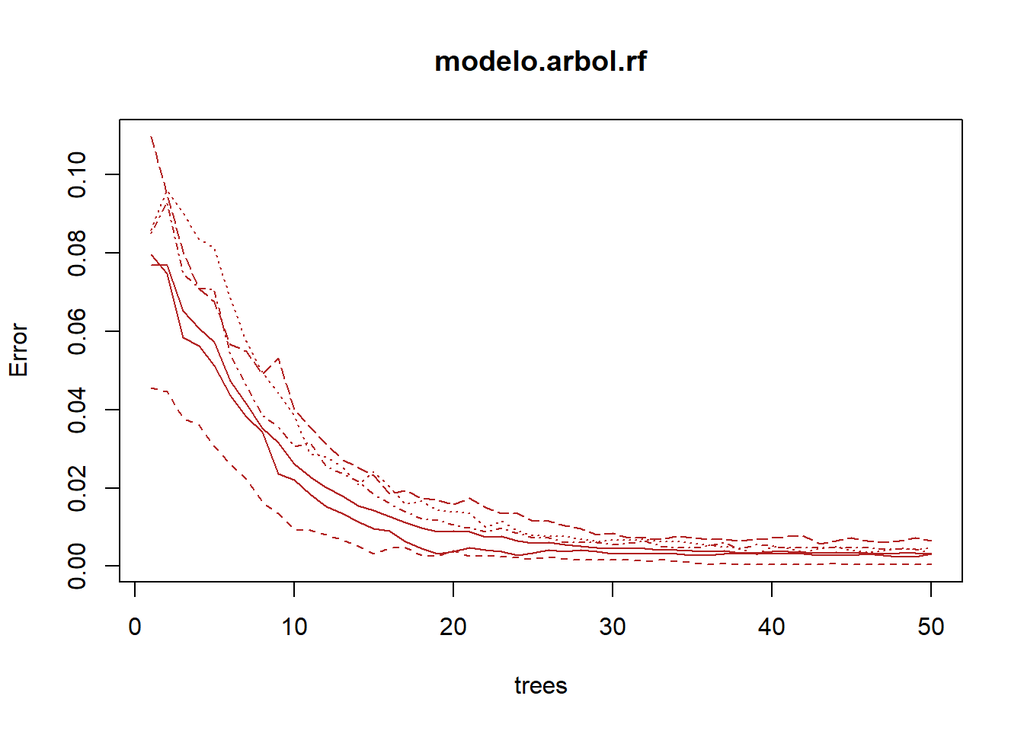

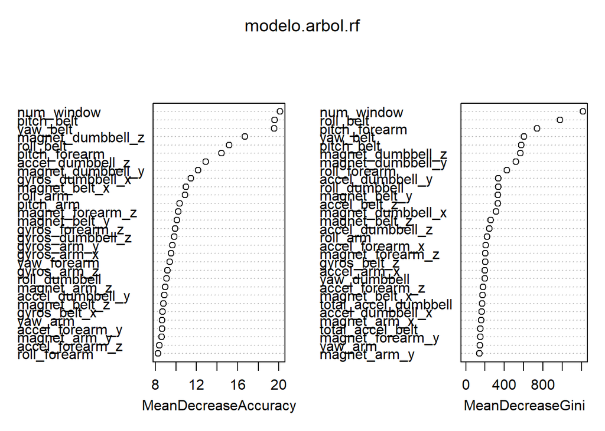

```
## Confusion Matrix and Statistics
##
##           df.test[, c("classe")]
## pred.arbol    A    B    C    D    E
##          A 1099    2    0    0    0
##          B    1  778    1    0    0
##          C    0    1  685    5    0
##          D    0    0    0  634    0
##          E    0    0    0    0  719
##
## Overall Statistics
##
##                Accuracy : 0.9975
##                  95% CI : (0.9953, 0.9988)
##     No Information Rate : 0.2803
##     P-Value [Acc > NIR] : < 2.2e-16
##
##                   Kappa : 0.9968
##
##  Mcnemar's Test P-Value : NA
##
## Statistics by Class:
##
##                      Class: A Class: B Class: C Class: D Class: E
## Sensitivity            0.9991   0.9962   0.9985   0.9922   1.0000
## Specificity            0.9993   0.9994   0.9981   1.0000   1.0000
## Pos Pred Value         0.9982   0.9974   0.9913   1.0000   1.0000
## Neg Pred Value         0.9996   0.9990   0.9997   0.9985   1.0000
## Prevalence             0.2803   0.1990   0.1748   0.1628   0.1832
## Detection Rate         0.2800   0.1982   0.1745   0.1615   0.1832
## Detection Prevalence   0.2805   0.1987   0.1761   0.1615   0.1832
## Balanced Accuracy      0.9992   0.9978   0.9983   0.9961   1.0000
```

We can see a very good performace in the classification task with this algorithm (about 99% accuracy). Finally, we use the validation data set to predict a submit our results.

```
##  1  2  3  4  5  6  7  8  9 10 11 12 13 14 15 16 17 18 19 20
##  B  A  B  A  A  E  D  B  A  A  B  C  B  A  E  E  A  B  B  B
## Levels: A B C D E
```